title: “Tugas Praktikum 5” author: “Cahyani Dyah Rofiana” date: “2023-09-26” output: html_document —

Uji stasioneritas pake plot

## Potong part 1

Potong part 2

```r
library(ggplot2)
library(tsibble)
library(tseries)
library(MASS)
```

```r
library(rio)
sta <- import("https://raw.githubusercontent.com/CahyaniDyahRofiana/PraktikumUTSMPDW/main/Data/data.csv")
sta
```

```
##      No CabaiMerahKeriting
## 1     1              56550
## 2     2              53200
## 3     3              48800
## 4     4              40450
## 5     5              58600
## 6     6              63200
## 7     7              53800
## 8     8              58750
## 9     9              55300
## 10   10              49500
## 11   11              54400
## 12   12              54650
## 13   13              54200
## 14   14              54000
```

[output cut: 125 more lines]

```r
str(data)
```

```
## function (..., list = character(), package = NULL, lib.loc = NULL, verbose = getOption("verbose"),
##     envir = .GlobalEnv, overwrite = TRUE)
```

mengubah data agar terbaca sebagai data deret waktu dengan fungsi `ts()`

```r
sta.ts <- ts(sta$CabaiMerahKeriting)
```

## Plot *Time Series*

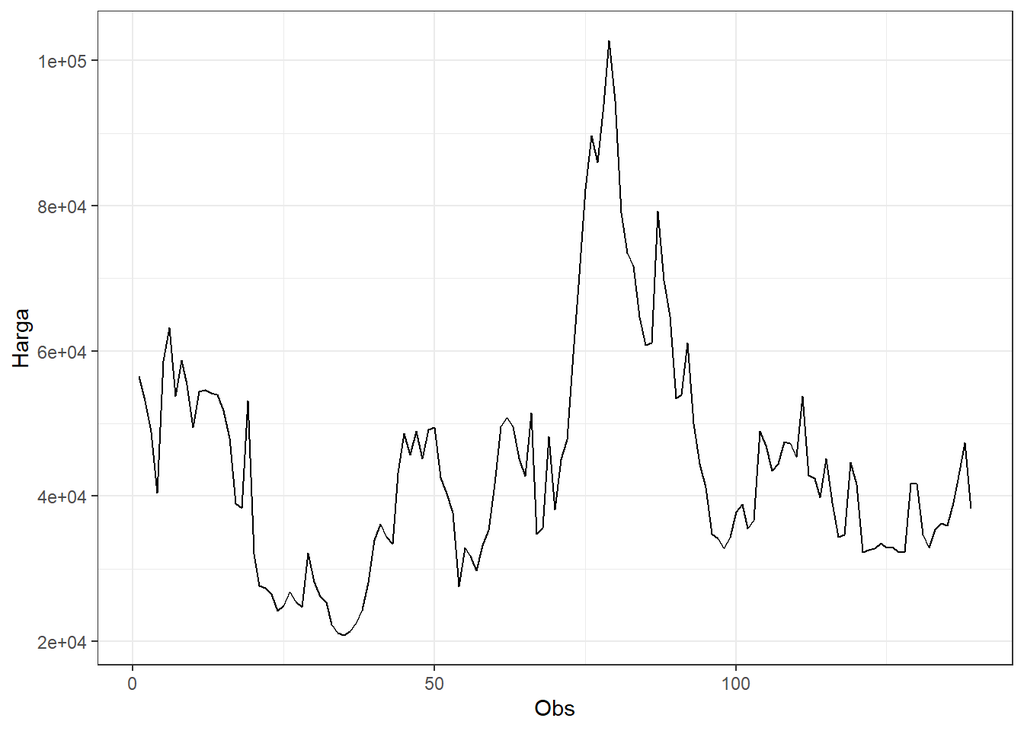

```r
plot <- sta.ts |> as_tsibble() |>
  ggplot(aes(x = sta$No, y = sta$CabaiMerahKeriting)) + geom_line() + theme_bw() +
  xlab("Obs") + ylab("Harga")
plot
```

```r
mean(sta$CabaiMerahKeriting)
```

```
## [1] 44473.74
```

### Plot ACF

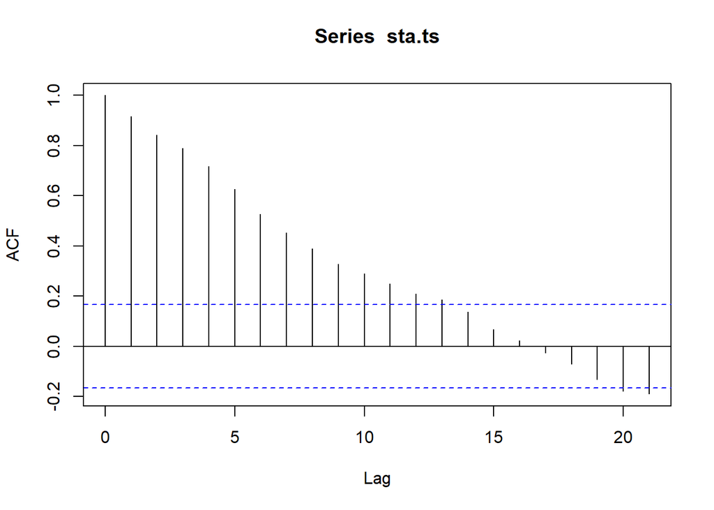

```r
acf(sta.ts)
```

Berdasarkan plot ACF, terlihat bahwa plot ACF pada data tersebut *tails off* atau turun secara lambat. Hal ini memungkinkan bahwa data tidak stasioner.

### Uji ADF

```r
tseries::adf.test(sta.ts)
```

```
##
##  Augmented Dickey-Fuller Test
##
## data:  sta.ts
## Dickey-Fuller = -3.0832, Lag order = 5, p-value = 0.1257
## alternative hypothesis: stationary
```

$H_0$ : Data tidak stasioner dalam rataan

$H_1$ : Data stasioner dalam rataan

Berdasarkan uji ADF tersebut, didapat *p-value* sebesar 0.1 yang lebih besar dari taraf nyata 5% sehingga terima $H_0$ dan menandakan bahwa data tidak stasioner dalam rataan. Hal ini sesuai dengan hasil eksplorasi menggunakan plot time series dan plot ACF.

### Plot Box-Cox

** uji box cox ga bisa kalau misal ada nilai amatan yang negatif

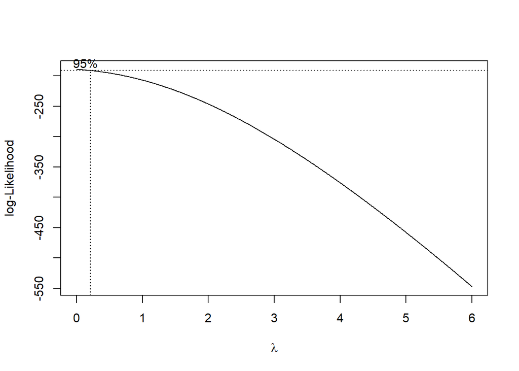

```r
index <- seq(1:139) #dibuat sesuai banyak amatan
bc = boxcox(sta.ts~index, lambda = seq(0,6,by=0.01))
```

```r
#Nilai Rounded Lambda
lambda <- bc$x[which.max(bc$y)]
lambda
```

```
## [1] 0
```

```r
#SK
bc$x[bc$y > max(bc$y) - 1/2 * qchisq(.95,1)]
```

```
##  [1] 0.00 0.01 0.02 0.03 0.04 0.05 0.06 0.07 0.08 0.09 0.10 0.11 0.12 0.13 0.14
## [16] 0.15 0.16 0.17 0.18 0.19 0.20 0.21
```

Gambar di atas menunjukkan nilai *rounded value* ($\lambda$) optimum sebesar **0** dan pada selang kepercayaan 95% nilai memiliki batas bawah **0** dan batas atas **0.21**. Selang tersebut tidak memuat nilai satu sehingga dapat dikatakan bahwa data tidak stasioner dalam ragam.

### Partisi Data

#### Bagian 1

```r
dt_sta1 <- sta.ts[1:83] |> ts()
mean(dt_sta1)
```

```
## [1] 45322.89
```

```r
var(dt_sta1)
```

```
## [1] 344776909
```

#### Plot Time Series

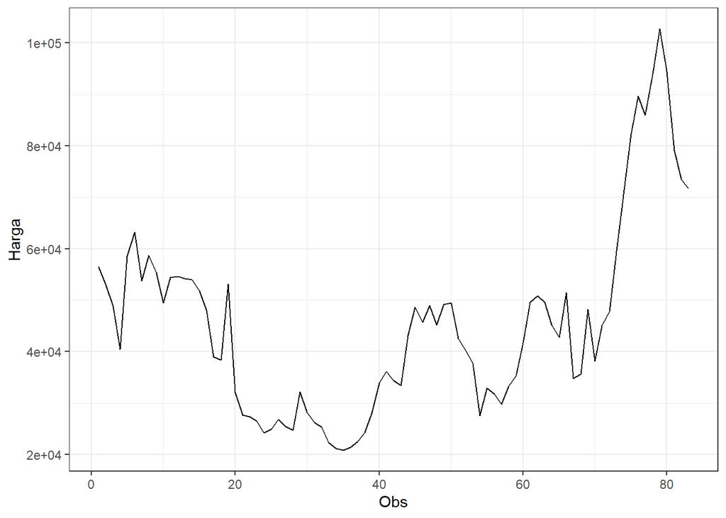

```r
dt_sta1 |> as_tsibble() |>
  ggplot(aes(x = index, y = value)) +
  geom_line() + theme_bw() +
  xlab("Obs") + ylab("Harga")
```

#### Plot ACF

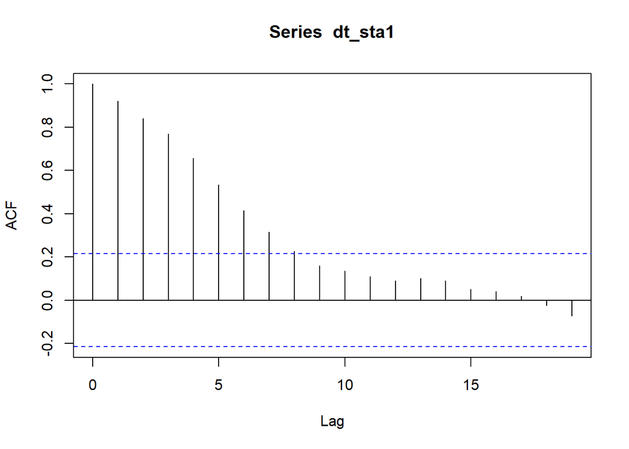

```r
acf(dt_sta1)
```

Berdasarkan plot ACF, terlihat bahwa plot ACF pada data tersebut *tails off* atau turun secara lambat. Hal ini memungkinkan bahwa data tidak stasioner.

#### Uji ADF

```r
tseries::adf.test(dt_sta1)
```

```
##
##  Augmented Dickey-Fuller Test
##
## data:  dt_sta1
## Dickey-Fuller = -2.5185, Lag order = 4, p-value = 0.3633
## alternative hypothesis: stationary
```

$H_0$ : Data tidak stasioner dalam rataan

$H_1$ : Data stasioner dalam rataan

Berdasarkan uji ADF tersebut, didapat *p-value* sebesar 0.3633 yang lebih besar dari taraf nyata 5% sehingga terima $H_0$ dan menandakan bahwa data tidak stasioner dalam rataan. Hal ini sesuai dengan hasil eksplorasi menggunakan plot time series dan plot ACF.

#### Plot Boxcox

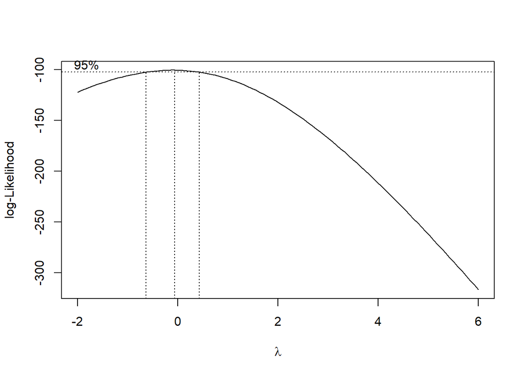

```r
index <- seq(1:83)
bc = boxcox(dt_sta1~index, lambda = seq(-2,6,by=1))
```

```r
#Nilai Rounded Lambda
lambda <- bc$x[which.max(bc$y)]
lambda
```

```
## [1] -0.06060606
```

```r
#SK
bc$x[bc$y > max(bc$y) - 1/2 * qchisq(.95,1)]
```

```
##  [1] -0.62626263 -0.54545455 -0.46464646 -0.38383838 -0.30303030 -0.22222222
##  [7] -0.14141414 -0.06060606  0.02020202  0.10101010  0.18181818  0.26262626
## [13]  0.34343434  0.42424242
```

Gambar di atas menunjukkan nilai *rounded value* ($\lambda$) optimum sebesar **-0.06060606** dan pada selang kepercayaan 95% nilai memiliki batas bawah **-0.62626263** dan batas atas **0.42424242**. Selang tersebut tidak memuat nilai satu sehingga dapat dikatakan bahwa data bangkitan tidak stasioner dalam ragam.

#### Bagian 2

```r
dt_sta2 <- sta.ts[84:139] |> ts()
mean(dt_sta2)
```

```
## [1] 43215.18
```

```r
var(dt_sta2)
```

```
## [1] 114923902
```

#### Plot Time Series

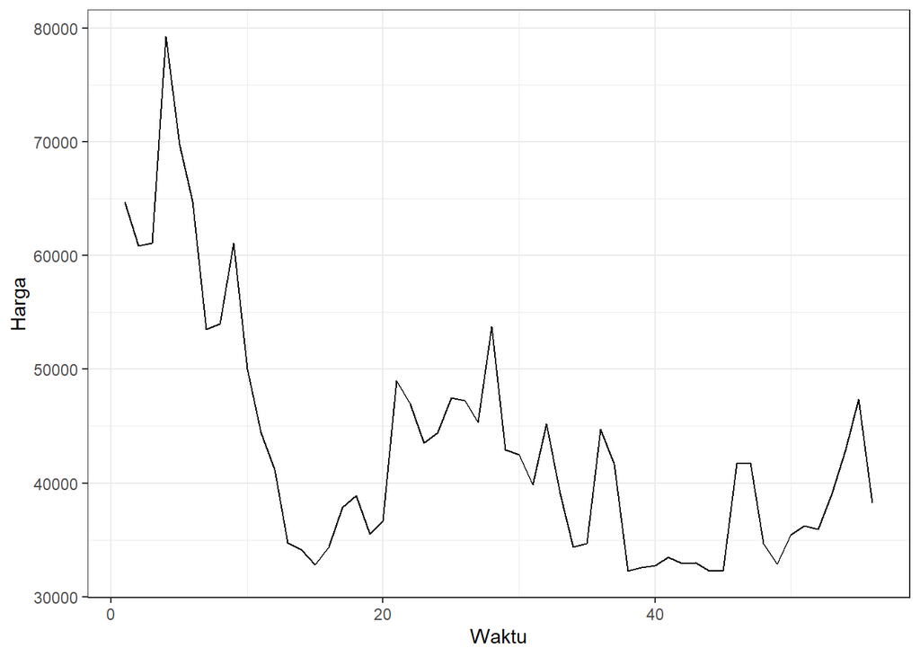

```r
dt_sta2 |> as_tsibble() |>
  ggplot(aes(x = index, y = value)) +
  geom_line() + theme_bw() +
  xlab("Waktu") + ylab("Harga")
```

Plot deret waktu di atas menunjukkan bahwa data tidak stasioner dalam rataan, ditandai dengan data yang tidak menyebar di sekitar nilai tengahnya (43215.18-an) dan tidak stasioner dalam ragam, ditandai dengan lebar pita yang cenderung tidak sama.

#### Plot ACF

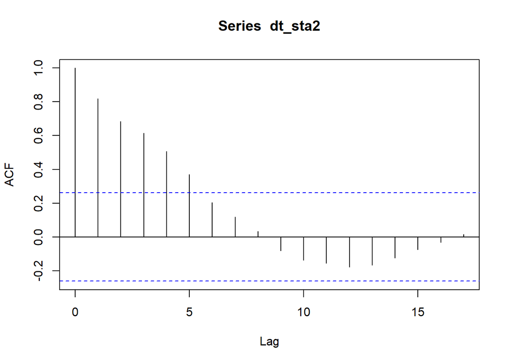

```r
acf(dt_sta2)
```

Berdasarkan plot ACF, terlihat bahwa plot ACF pada data tersebut cenderung *tails off* dan membentuk gelombang sinus.

#### Uji ADF

```r
adf.test(dt_sta2)
```

```
##
##  Augmented Dickey-Fuller Test
##
## data:  dt_sta2
## Dickey-Fuller = -2.6996, Lag order = 3, p-value = 0.2925
## alternative hypothesis: stationary
```

```r
tseries::adf.test(dt_sta2)
```

```
##
##  Augmented Dickey-Fuller Test
##
## data:  dt_sta2
## Dickey-Fuller = -2.6996, Lag order = 3, p-value = 0.2925
## alternative hypothesis: stationary
```

$H_0$ : Data tidak stasioner dalam rataan

$H_1$ : Data stasioner dalam rataan

Berdasarkan uji ADF tersebut, didapat *p-value* sebesar 0.2925 yang lebih besar dari taraf nyata 5% sehingga terima $H_0$ dan menandakan bahwa data tidak stasioner dalam rataan. Hal ini sesuai dengan hasil eksplorasi menggunakan plot time series dan plot ACF.

#### Plot Boxcox

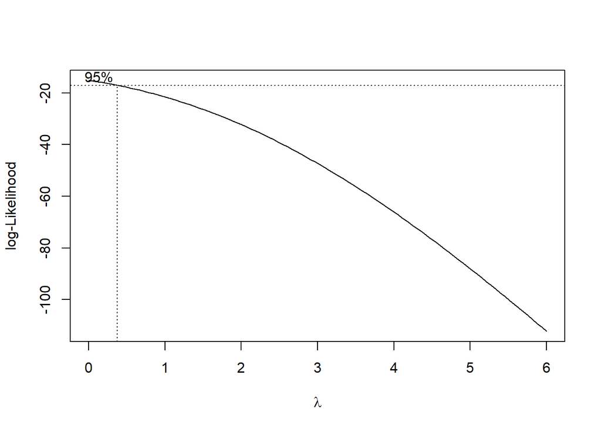

```r
index <- seq(84:139)
bc = boxcox(dt_sta2~index, lambda = seq(0,6,by=1))
```

```r
#Nilai Rounded Lambda
lambda <- bc$x[which.max(bc$y)]
lambda
```

```
## [1] 0
```

```r
#SK
bc$x[bc$y > max(bc$y) - 1/2 * qchisq(.95,1)]
```

```
## [1] 0.00000000 0.06060606 0.12121212 0.18181818 0.24242424 0.30303030 0.36363636
```

Gambar di atas menunjukkan nilai *rounded value* ($\lambda$) optimum sebesar **0** dan pada selang kepercayaan 95% nilai memiliki batas bawah **0** dan batas atas **0.36363636**. Selang tersebut tidak memuat nilai satu sehingga dapat dikatakan bahwa data bangkitan tidak stasioner dalam ragam.

# Kesimpulan

**Data Harga Cabai Merah Keriting di Kota Bogor pada merupakan data yang tidak stasioner dalam rataan dan ragam**, baik secara keseluruhan data maupun saat dibagi menjadi dua partisi data. Hal ini ditunjukkan oleh plot ACF yang cenderung *tails off* dan keputusan uji ADF yang terima $H_0$ sehingga menandakan bahwa data tersebut tidak stasioner dalam rataan. Selain itu, plot Box-Cox menunjukkan rounded value dengan selang kepercayaan 95% tidak memuat nilai satu sehingga dapat dikatakan bahwa data bangkitan tidak stasioner dalam ragam.